# WS02_7CS074

Note that:

- Question 1-5 are answer throughout the code in this notebook.
- Detailed answer for question 6-8 are answered in the report.

```python
import pandas as pd
import numpy as np
import matplotlib.pyplot as plt
%matplotlib inline
```

```python
dataset = pd.read_csv('/Users/rianyan/Desktop/train_ctrUa4K.csv')
```

```python
dataset.head()
```

|  | Loan_ID | Gender | Married | Dependents | Education | Self_Employed | ApplicantIncome | CoapplicantIncome | LoanAmount | Loan_Amount_Term | Credit_History | Property_Area | Loan_Status |
| --- | --- | --- | --- | --- | --- | --- | --- | --- | --- | --- | --- | --- | --- |
| 0 | LP001002 | Male | No | 0 | Graduate | No | 5849 | 0.0 | NaN | 360.0 | 1.0 | Urban | Y |
| 1 | LP001003 | Male | Yes | 1 | Graduate | No | 4583 | 1508.0 | 128.0 | 360.0 | 1.0 | Rural | N |
| 2 | LP001005 | Male | Yes | 0 | Graduate | Yes | 3000 | 0.0 | 66.0 | 360.0 | 1.0 | Urban | Y |
| 3 | LP001006 | Male | Yes | 0 | Not Graduate | No | 2583 | 2358.0 | 120.0 | 360.0 | 1.0 | Urban | Y |
| 4 | LP001008 | Male | No | 0 | Graduate | No | 6000 | 0.0 | 141.0 | 360.0 | 1.0 | Urban | Y |

```python
dataset.shape
```

```
(614, 13)
```

```python
dataset = dataset.sample(n=550, random_state=72)
```

```python
dataset.to_csv('RianYan_2424072.csv')
```

```python
data = pd.read_csv('RianYan_2424072.csv')
```

```python
data.head()
```

|  | Unnamed: 0 | Loan_ID | Gender | Married | Dependents | Education | Self_Employed | ApplicantIncome | CoapplicantIncome | LoanAmount | Loan_Amount_Term | Credit_History | Property_Area | Loan_Status |
| --- | --- | --- | --- | --- | --- | --- | --- | --- | --- | --- | --- | --- | --- | --- |
| 0 | 206 | LP001693 | Female | No | 0 | Graduate | No | 3244 | 0.0 | 80.0 | 360.0 | 1.0 | Urban | Y |
| 1 | 576 | LP002872 | NaN | Yes | 0 | Graduate | No | 3087 | 2210.0 | 136.0 | 360.0 | 0.0 | Semiurban | N |
| 2 | 198 | LP001671 | Female | Yes | 0 | Graduate | No | 3416 | 2816.0 | 113.0 | 360.0 | NaN | Semiurban | Y |
| 3 | 587 | LP002917 | Female | No | 0 | Not Graduate | No | 2165 | 0.0 | 70.0 | 360.0 | 1.0 | Semiurban | Y |
| 4 | 90 | LP001316 | Male | Yes | 0 | Graduate | No | 2958 | 2900.0 | 131.0 | 360.0 | 1.0 | Semiurban | Y |

```python
data = data.drop('Unnamed: 0', axis = 1)
```

Q1. Use and explain the following DataFrame functions/properties on your data. describe() size ndim shape Hint: use print() to see what are the outputs.

```python
data.describe()
```

|  | ApplicantIncome | CoapplicantIncome | LoanAmount | Loan_Amount_Term | Credit_History |
| --- | --- | --- | --- | --- | --- |
| count | 550.000000 | 550.000000 | 528.000000 | 538.000000 | 503.000000 |
| mean | 5482.732727 | 1676.422036 | 147.928030 | 342.156134 | 0.840954 |
| std | 6341.658306 | 3059.776181 | 85.214822 | 65.092098 | 0.366083 |
| min | 150.000000 | 0.000000 | 9.000000 | 12.000000 | 0.000000 |
| 25% | 2877.500000 | 0.000000 | 102.000000 | 360.000000 | 1.000000 |
| 50% | 3812.500000 | 1211.500000 | 128.000000 | 360.000000 | 1.000000 |
| 75% | 5844.000000 | 2324.000000 | 168.500000 | 360.000000 | 1.000000 |
| max | 81000.000000 | 41667.000000 | 700.000000 | 480.000000 | 1.000000 |

Data.describe(): The data.describe() function in pandas generates descriptive statistics of a DataFrame, including measures such as count, mean, standard deviation, minimum, and maximum values, as well as quartiles (25%, 50%, and 75%) for numerical columns.

```python
print(data.size)
```

```
7150
```

Data.size: The data.size attribute in pandas returns the total number of elements in a DataFrame, calculated as the number of rows multiplied by the number of columns. Print(data.size) return the result as 7150, meaning there is in total 7150 elements in the dataset.

```python
print(data.shape[0], data.shape[1])
```

```
550 13
```

Data.shape: The data.shape attribute in pandas returns a tuple representing the dimensions of the DataFrame. Specifically, it returns (number of rows, number of columns) in the DataFrame. In this dataset, there are 550 rows and 13 columns.

```python
print(data.ndim)
```

```
2
```

Data.ndim: The data.ndim attribute in pandas returns the number of dimensions of the DataFrame, which is always 2 for a DataFrame (rows and columns).

```python
print(data.shape)
```

```
(550, 13)
```

Q2. Is there any difference between dimensions of the original dataset and the new dataset? If yes, what is the difference?

- Answer: There is no difference since the dimention are all 2.

Q3. What are the possible values 'Education' can take? Write code to display all the possible values of 'Education'.

```python
data.value_counts('Education')
```

```
Education
Graduate        428
Not Graduate    122
Name: count, dtype: int64
```

```python
data.Education.unique()
```

```
array(['Graduate', 'Not Graduate'], dtype=object)
```

Possible values for 'Education' are just 'Graduate' and 'Not Graduate'. 'Education' is a binary variable.

Data Analysis

```python
columns = data.columns
print(columns)
```

```
Index(['Loan_ID', 'Gender', 'Married', 'Dependents', 'Education',
       'Self_Employed', 'ApplicantIncome', 'CoapplicantIncome', 'LoanAmount',
       'Loan_Amount_Term', 'Credit_History', 'Property_Area', 'Loan_Status'],
      dtype='object')
```

```python
data.head()
```

|  | Loan_ID | Gender | Married | Dependents | Education | Self_Employed | ApplicantIncome | CoapplicantIncome | LoanAmount | Loan_Amount_Term | Credit_History | Property_Area | Loan_Status |
| --- | --- | --- | --- | --- | --- | --- | --- | --- | --- | --- | --- | --- | --- |
| 0 | LP001693 | Female | No | 0 | Graduate | No | 3244 | 0.0 | 80.0 | 360.0 | 1.0 | Urban | Y |
| 1 | LP002872 | NaN | Yes | 0 | Graduate | No | 3087 | 2210.0 | 136.0 | 360.0 | 0.0 | Semiurban | N |
| 2 | LP001671 | Female | Yes | 0 | Graduate | No | 3416 | 2816.0 | 113.0 | 360.0 | NaN | Semiurban | Y |
| 3 | LP002917 | Female | No | 0 | Not Graduate | No | 2165 | 0.0 | 70.0 | 360.0 | 1.0 | Semiurban | Y |
| 4 | LP001316 | Male | Yes | 0 | Graduate | No | 2958 | 2900.0 | 131.0 | 360.0 | 1.0 | Semiurban | Y |

Analysis of 'ApplicantIncome' & 'LoanAmount'

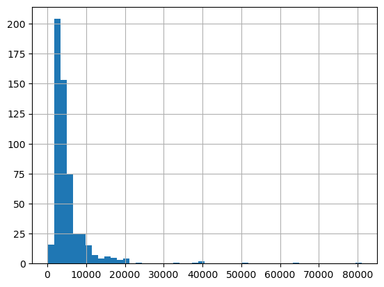

```python
data['ApplicantIncome'].hist(bins=50)
```

Q4. Use boxplot and histogram on 'ApplicantIncome' to visualise its distribution.

- 4a. What are the extreme values? Are there any outliers(s) exist in this dataset? Explain with example based on the 'ApplicantIncome'?

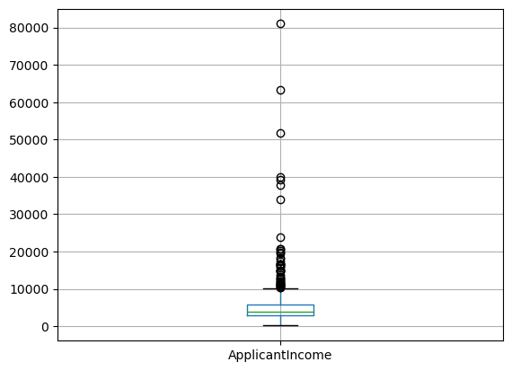

```python
data.boxplot(column = 'ApplicantIncome')
```

Identify Extreme values

```python
Max_value = data.ApplicantIncome.max()
Min_value = data.ApplicantIncome.min()
print(Max_value, Min_value)
```

```
81000 150
```

The result returns as 81000 and 150. These two values are extreme values.

Identity outliers

In boxplot, outliers are the values outside of the whiskers, which are the value greater than 1.5*IQR above the upper quartile or below the lower quartile. From the boxplot shown above, the varibale ‘ApplicantIncome’ has numerous outliers since it is clear to see that there are lots of points above the upper whisker.

```python
q1 = data.ApplicantIncome.quantile(0.25)
q3 = data.ApplicantIncome.quantile(0.75)
iqr = q3 - q1
```

```python
print(q1, q3, iqr)
```

```
2877.5 5844.0 2966.5
```

```python
lower_threshold = q1 - 1.5 * iqr
upper_threshold = q3 + 1.5 * iqr
```

```python
print (lower_threshold, upper_threshold)
```

```
-1572.25 10293.75
```

```python
outliers = data[data['ApplicantIncome'] > upper_threshold]
```

```python
print(outliers)
```

```
      Loan_ID  Gender Married Dependents     Education Self_Employed  \
13   LP001369    Male     Yes          2      Graduate            No
18   LP002855    Male     Yes          2      Graduate            No
51   LP001508    Male     Yes          2      Graduate            No
61   LP002386    Male      No          0      Graduate           NaN
73   LP001020    Male     Yes          1      Graduate            No
80   LP001585     NaN     Yes         3+      Graduate            No
95   LP001422  Female      No          0      Graduate            No
106  LP002959  Female     Yes          1      Graduate            No
117  LP002731  Female      No          0  Not Graduate           Yes
126  LP001637    Male     Yes          1      Graduate            No
131  LP002813  Female     Yes          1      Graduate           Yes
134  LP001640    Male     Yes          0      Graduate           Yes
145  LP001448     NaN     Yes         3+      Graduate            No
165  LP002729    Male      No          1      Graduate            No
```

[output cut: 128 more lines]

```python
print(outliers.count())
```

```
Loan_ID              46
Gender               43
Married              46
Dependents           45
Education            46
Self_Employed        44
ApplicantIncome      46
CoapplicantIncome    46
LoanAmount           44
Loan_Amount_Term     46
Credit_History       44
Property_Area        46
Loan_Status          46
dtype: int64
```

4b. Are the results of both the plots comparable? Are there any differences in the two plots? What are the key differences?

The results of the boxplot and histogram for detecting extreme values and outliers in the 'applicant income' variable are comparable, but they offer different perspectives. Boxplot directly shows outliers as points outside the whiskers, making it easy to identify extreme values. Histogram highlights the frequency distribution of income values, with outliers appearing as isolated bars or bars with very low frequencies at the extremes.While both plots are useful for detecting extreme values and outliers, the boxplot is more direct and clear for outlier identification, whereas the histogram provides a detailed view of the data distribution.

Categorical Analysis

```python
data['Credit_History'].value_counts()
```

```
Credit_History
1.0    423
0.0     80
Name: count, dtype: int64
```

```python
credit_history = data['Credit_History'].value_counts(ascending=True)

def transform (x):
    return x.map({'Y':1,'N':0}).mean()

loan_probability = data.pivot_table(values='Loan_Status', index=['Credit_History'],
aggfunc = transform)

print('Frequency Table for Credit History:')
print(credit_history)
print('\nProbability of getting loan for each Credit History class:')
print(loan_probability)
```

```
Frequency Table for Credit History:
Credit_History
0.0     80
1.0    423
Name: count, dtype: int64

Probability of getting loan for each Credit History class:
                Loan_Status
Credit_History
0.0                0.062500
1.0                0.801418
```

```python
data['Loan_Status'].value_counts()
```

```
Loan_Status
Y    378
N    172
Name: count, dtype: int64
```

```python
data.shape
```

```
(550, 13)
```

```python
data.head()
```

|  | Loan_ID | Gender | Married | Dependents | Education | Self_Employed | ApplicantIncome | CoapplicantIncome | LoanAmount | Loan_Amount_Term | Credit_History | Property_Area | Loan_Status |
| --- | --- | --- | --- | --- | --- | --- | --- | --- | --- | --- | --- | --- | --- |
| 0 | LP001693 | Female | No | 0 | Graduate | No | 3244 | 0.0 | 80.0 | 360.0 | 1.0 | Urban | Y |
| 1 | LP002872 | NaN | Yes | 0 | Graduate | No | 3087 | 2210.0 | 136.0 | 360.0 | 0.0 | Semiurban | N |
| 2 | LP001671 | Female | Yes | 0 | Graduate | No | 3416 | 2816.0 | 113.0 | 360.0 | NaN | Semiurban | Y |
| 3 | LP002917 | Female | No | 0 | Not Graduate | No | 2165 | 0.0 | 70.0 | 360.0 | 1.0 | Semiurban | Y |
| 4 | LP001316 | Male | Yes | 0 | Graduate | No | 2958 | 2900.0 | 131.0 | 360.0 | 1.0 | Semiurban | Y |

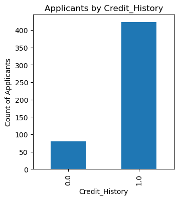

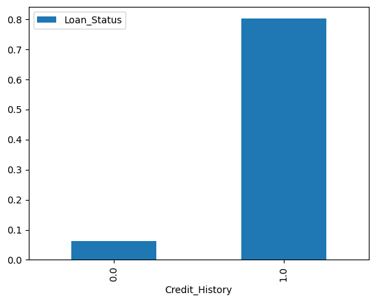

```python
fig = plt.figure(figsize=(8,4))
ax1 = fig.add_subplot(121)
ax1.set_xlabel('Credit_History')
ax1.set_ylabel('Count of Applicants')
ax1.set_title("Applicants by Credit_History")
credit_history.plot(kind='bar')
plt.show()
ax2 = fig.add_subplot(122)
ax2.set_xlabel('Credit_History')
ax2.set_ylabel('Probability of getting loan')
ax2.set_title("Probability of getting loan by credit history")
loan_probability.plot(kind = 'bar')
plt.show()
```

Data Preprocessing

```python
data.Gender.value_counts()
```

```
Gender
Male      435
Female    103
Name: count, dtype: int64
```

Filling missing values by mean

```python
def missing_value (x):
    return sum(x.isnull())
data.apply(missing_value, axis = 0)
```

```
Loan_ID               0
Gender               12
Married               3
Dependents           15
Education             0
Self_Employed        29
ApplicantIncome       0
CoapplicantIncome     0
LoanAmount           22
Loan_Amount_Term     12
Credit_History       47
Property_Area         0
Loan_Status           0
dtype: int64
```

```python
data.head()
```

|  | Loan_ID | Gender | Married | Dependents | Education | Self_Employed | ApplicantIncome | CoapplicantIncome | LoanAmount | Loan_Amount_Term | Credit_History | Property_Area | Loan_Status |
| --- | --- | --- | --- | --- | --- | --- | --- | --- | --- | --- | --- | --- | --- |
| 0 | LP001693 | Female | No | 0 | Graduate | No | 3244 | 0.0 | 80.0 | 360.0 | 1.0 | Urban | Y |
| 1 | LP002872 | NaN | Yes | 0 | Graduate | No | 3087 | 2210.0 | 136.0 | 360.0 | 0.0 | Semiurban | N |
| 2 | LP001671 | Female | Yes | 0 | Graduate | No | 3416 | 2816.0 | 113.0 | 360.0 | NaN | Semiurban | Y |
| 3 | LP002917 | Female | No | 0 | Not Graduate | No | 2165 | 0.0 | 70.0 | 360.0 | 1.0 | Semiurban | Y |
| 4 | LP001316 | Male | Yes | 0 | Graduate | No | 2958 | 2900.0 | 131.0 | 360.0 | 1.0 | Semiurban | Y |

```python
data.LoanAmount.fillna(data.LoanAmount.mean(), inplace = True)
```

```python
data.apply(missing_value, axis=0)
```

```
Loan_ID               0
Gender               12
Married               3
Dependents           15
Education             0
Self_Employed        29
ApplicantIncome       0
CoapplicantIncome     0
LoanAmount            0
Loan_Amount_Term     12
Credit_History       47
Property_Area         0
Loan_Status           0
dtype: int64
```

```python
data.shape
```

```
(550, 13)
```

```python
data.head()
```

|  | Loan_ID | Gender | Married | Dependents | Education | Self_Employed | ApplicantIncome | CoapplicantIncome | LoanAmount | Loan_Amount_Term | Credit_History | Property_Area | Loan_Status |
| --- | --- | --- | --- | --- | --- | --- | --- | --- | --- | --- | --- | --- | --- |
| 0 | LP001693 | Female | No | 0 | Graduate | No | 3244 | 0.0 | 80.0 | 360.0 | 1.0 | Urban | Y |
| 1 | LP002872 | NaN | Yes | 0 | Graduate | No | 3087 | 2210.0 | 136.0 | 360.0 | 0.0 | Semiurban | N |
| 2 | LP001671 | Female | Yes | 0 | Graduate | No | 3416 | 2816.0 | 113.0 | 360.0 | NaN | Semiurban | Y |
| 3 | LP002917 | Female | No | 0 | Not Graduate | No | 2165 | 0.0 | 70.0 | 360.0 | 1.0 | Semiurban | Y |
| 4 | LP001316 | Male | Yes | 0 | Graduate | No | 2958 | 2900.0 | 131.0 | 360.0 | 1.0 | Semiurban | Y |

```python
data.to_csv('new_train.csv')
```

It will be interseting to know how much loan amount could be offered to which sort of people based on their 'Education' and 'Self Employed' statues

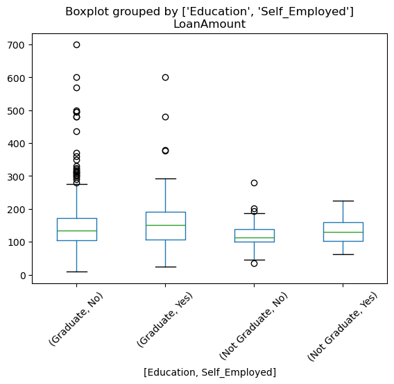

```python
data.boxplot(column = 'LoanAmount', by = ['Education', 'Self_Employed'], grid=False, rot=45, fontsize= 10)
```

```python
data.Self_Employed.value_counts()
```

```
Self_Employed
No     445
Yes     76
Name: count, dtype: int64
```

```python
data.apply(missing_value, axis=0)
```

```
Loan_ID               0
Gender               12
Married               3
Dependents           15
Education             0
Self_Employed        29
ApplicantIncome       0
CoapplicantIncome     0
LoanAmount            0
Loan_Amount_Term     12
Credit_History       47
Property_Area         0
Loan_Status           0
dtype: int64
```

```python
data.Self_Employed.fillna('No', inplace=True)
```

```python
data.apply(missing_value, axis=0)
```

```
Loan_ID               0
Gender               12
Married               3
Dependents           15
Education             0
Self_Employed         0
ApplicantIncome       0
CoapplicantIncome     0
LoanAmount            0
Loan_Amount_Term     12
Credit_History       47
Property_Area         0
Loan_Status           0
dtype: int64
```

```python
data.describe()
```

|  | ApplicantIncome | CoapplicantIncome | LoanAmount | Loan_Amount_Term | Credit_History |
| --- | --- | --- | --- | --- | --- |
| count | 550.000000 | 550.000000 | 550.000000 | 538.000000 | 503.000000 |
| mean | 5482.732727 | 1676.422036 | 147.928030 | 342.156134 | 0.840954 |
| std | 6341.658306 | 3059.776181 | 83.489965 | 65.092098 | 0.366083 |
| min | 150.000000 | 0.000000 | 9.000000 | 12.000000 | 0.000000 |
| 25% | 2877.500000 | 0.000000 | 104.000000 | 360.000000 | 1.000000 |
| 50% | 3812.500000 | 1211.500000 | 130.000000 | 360.000000 | 1.000000 |
| 75% | 5844.000000 | 2324.000000 | 165.000000 | 360.000000 | 1.000000 |
| max | 81000.000000 | 41667.000000 | 700.000000 | 480.000000 | 1.000000 |

Deal with missing values and outliers for LoanAmount

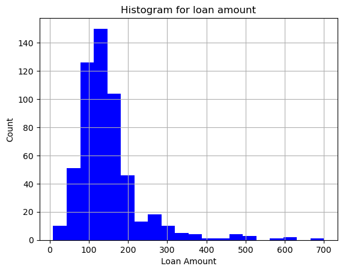

```python
plt.hist(data['LoanAmount'], 20, facecolor='b')
plt.xlabel('Loan Amount')
plt.ylabel('Count')
plt.title('Histogram for loan amount')
plt.grid(True)
plt.show()
```

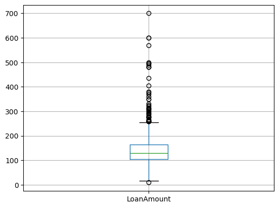

```python
data.boxplot(column='LoanAmount')
```

```python
data['LoanAmount_log'] = np.log(data.LoanAmount)
```

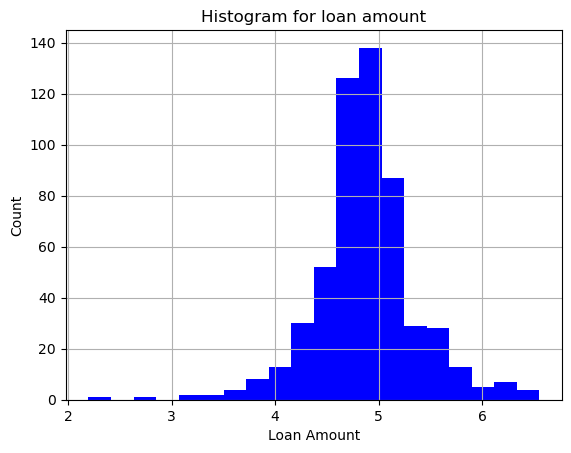

```python
plt.hist(data['LoanAmount_log'], 20, facecolor='b')
plt.xlabel('Loan Amount')
plt.ylabel('Count')
plt.title('Histogram for loan amount')
plt.grid(True)
plt.show()
```

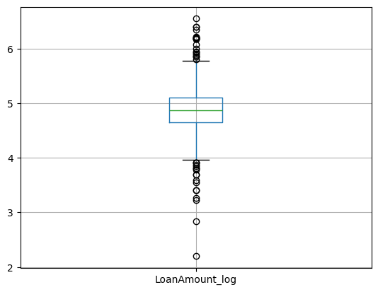

```python
data.boxplot(column='LoanAmount_log')
```

```python
data.head()
```

|  | Loan_ID | Gender | Married | Dependents | Education | Self_Employed | ApplicantIncome | CoapplicantIncome | LoanAmount | Loan_Amount_Term | Credit_History | Property_Area | Loan_Status | LoanAmount_log |
| --- | --- | --- | --- | --- | --- | --- | --- | --- | --- | --- | --- | --- | --- | --- |
| 0 | LP001693 | Female | No | 0 | Graduate | No | 3244 | 0.0 | 80.0 | 360.0 | 1.0 | Urban | Y | 4.382027 |
| 1 | LP002872 | NaN | Yes | 0 | Graduate | No | 3087 | 2210.0 | 136.0 | 360.0 | 0.0 | Semiurban | N | 4.912655 |
| 2 | LP001671 | Female | Yes | 0 | Graduate | No | 3416 | 2816.0 | 113.0 | 360.0 | NaN | Semiurban | Y | 4.727388 |
| 3 | LP002917 | Female | No | 0 | Not Graduate | No | 2165 | 0.0 | 70.0 | 360.0 | 1.0 | Semiurban | Y | 4.248495 |
| 4 | LP001316 | Male | Yes | 0 | Graduate | No | 2958 | 2900.0 | 131.0 | 360.0 | 1.0 | Semiurban | Y | 4.875197 |

```python
data.describe()
```

|  | ApplicantIncome | CoapplicantIncome | LoanAmount | Loan_Amount_Term | Credit_History | LoanAmount_log |
| --- | --- | --- | --- | --- | --- | --- |
| count | 550.000000 | 550.000000 | 550.000000 | 538.000000 | 503.000000 | 550.000000 |
| mean | 5482.732727 | 1676.422036 | 147.928030 | 342.156134 | 0.840954 | 4.875161 |
| std | 6341.658306 | 3059.776181 | 83.489965 | 65.092098 | 0.366083 | 0.491616 |
| min | 150.000000 | 0.000000 | 9.000000 | 12.000000 | 0.000000 | 2.197225 |
| 25% | 2877.500000 | 0.000000 | 104.000000 | 360.000000 | 1.000000 | 4.644391 |
| 50% | 3812.500000 | 1211.500000 | 130.000000 | 360.000000 | 1.000000 | 4.867534 |
| 75% | 5844.000000 | 2324.000000 | 165.000000 | 360.000000 | 1.000000 | 5.105945 |
| max | 81000.000000 | 41667.000000 | 700.000000 | 480.000000 | 1.000000 | 6.551080 |

```python
del data['LoanAmount']
```

```python
data.head()
```

|  | Loan_ID | Gender | Married | Dependents | Education | Self_Employed | ApplicantIncome | CoapplicantIncome | Loan_Amount_Term | Credit_History | Property_Area | Loan_Status | LoanAmount_log |
| --- | --- | --- | --- | --- | --- | --- | --- | --- | --- | --- | --- | --- | --- |
| 0 | LP001693 | Female | No | 0 | Graduate | No | 3244 | 0.0 | 360.0 | 1.0 | Urban | Y | 4.382027 |
| 1 | LP002872 | NaN | Yes | 0 | Graduate | No | 3087 | 2210.0 | 360.0 | 0.0 | Semiurban | N | 4.912655 |
| 2 | LP001671 | Female | Yes | 0 | Graduate | No | 3416 | 2816.0 | 360.0 | NaN | Semiurban | Y | 4.727388 |
| 3 | LP002917 | Female | No | 0 | Not Graduate | No | 2165 | 0.0 | 360.0 | 1.0 | Semiurban | Y | 4.248495 |
| 4 | LP001316 | Male | Yes | 0 | Graduate | No | 2958 | 2900.0 | 360.0 | 1.0 | Semiurban | Y | 4.875197 |

```python
#revise what variables still have missing values

data.apply(missing_value, axis=0)
```

```
Loan_ID               0
Gender               12
Married               3
Dependents           15
Education             0
Self_Employed         0
ApplicantIncome       0
CoapplicantIncome     0
Loan_Amount_Term     12
Credit_History       47
Property_Area         0
Loan_Status           0
LoanAmount_log        0
dtype: int64
```

```python
#Deal with all the rest missing values

data['Gender'].fillna(data['Gender'].mode()[0], inplace = True)
data['Married'].fillna(data['Married'].mode()[0], inplace = True)
data['Dependents'].fillna(data['Dependents'].mode()[0], inplace = True)
data['Loan_Amount_Term'].fillna(data['Loan_Amount_Term'].mode()[0], inplace = True)
data['Credit_History'].fillna(data['Credit_History'].mode()[0], inplace = True)
```

```python
data.apply(lambda x : sum(x.isnull()), axis=0)
```

```
Loan_ID              0
Gender               0
Married              0
Dependents           0
Education            0
Self_Employed        0
ApplicantIncome      0
CoapplicantIncome    0
Loan_Amount_Term     0
Credit_History       0
Property_Area        0
Loan_Status          0
LoanAmount_log       0
dtype: int64
```

Q5. Use LabelEncoder, to convert categorical variables into numeric. Hint: You will first need to identify categorial values.

```python
#identify all categorical columns

data.dtypes
```

```
Loan_ID               object
Gender                object
Married               object
Dependents            object
Education             object
Self_Employed         object
ApplicantIncome        int64
CoapplicantIncome    float64
Loan_Amount_Term     float64
Credit_History       float64
Property_Area         object
Loan_Status           object
LoanAmount_log       float64
dtype: object
```

```python
columns = list(data)
print (columns)
```

```
['Loan_ID', 'Gender', 'Married', 'Dependents', 'Education', 'Self_Employed', 'ApplicantIncome', 'CoapplicantIncome', 'Loan_Amount_Term', 'Credit_History', 'Property_Area', 'Loan_Status', 'LoanAmount_log']
```

```python
#save categorical columns attributes into an array c_columns

c_columns = list(data.select_dtypes(exclude=['float64', 'int64']))
print (c_columns)
```

```
['Loan_ID', 'Gender', 'Married', 'Dependents', 'Education', 'Self_Employed', 'Property_Area', 'Loan_Status']
```

```python
c_columns.pop(0)
print (c_columns)
```

```
['Gender', 'Married', 'Dependents', 'Education', 'Self_Employed', 'Property_Area', 'Loan_Status']
```

```python
#import LabelEncoder from scikit-learn
from sklearn.preprocessing import LabelEncoder

#import copy to save the transformed dataset to a new dataframe
import copy

#initialize LabelEncoder
le = LabelEncoder()

#save the transformed dataset to new dataframe
data_trans = copy.deepcopy(data)

#transform categorical value to numeric value
for i in c_columns:
    data_trans [i] = le.fit_transform(data[i])
```

```python
data_trans.head()
```

|  | Loan_ID | Gender | Married | Dependents | Education | Self_Employed | ApplicantIncome | CoapplicantIncome | Loan_Amount_Term | Credit_History | Property_Area | Loan_Status | LoanAmount_log |
| --- | --- | --- | --- | --- | --- | --- | --- | --- | --- | --- | --- | --- | --- |
| 0 | LP001693 | 0 | 0 | 0 | 0 | 0 | 3244 | 0.0 | 360.0 | 1.0 | 2 | 1 | 4.382027 |
| 1 | LP002872 | 1 | 1 | 0 | 0 | 0 | 3087 | 2210.0 | 360.0 | 0.0 | 1 | 0 | 4.912655 |
| 2 | LP001671 | 0 | 1 | 0 | 0 | 0 | 3416 | 2816.0 | 360.0 | 1.0 | 1 | 1 | 4.727388 |
| 3 | LP002917 | 0 | 0 | 0 | 1 | 0 | 2165 | 0.0 | 360.0 | 1.0 | 1 | 1 | 4.248495 |
| 4 | LP001316 | 1 | 1 | 0 | 0 | 0 | 2958 | 2900.0 | 360.0 | 1.0 | 1 | 1 | 4.875197 |

```python
data.head()
```

|  | Loan_ID | Gender | Married | Dependents | Education | Self_Employed | ApplicantIncome | CoapplicantIncome | Loan_Amount_Term | Credit_History | Property_Area | Loan_Status | LoanAmount_log |
| --- | --- | --- | --- | --- | --- | --- | --- | --- | --- | --- | --- | --- | --- |
| 0 | LP001693 | Female | No | 0 | Graduate | No | 3244 | 0.0 | 360.0 | 1.0 | Urban | Y | 4.382027 |
| 1 | LP002872 | Male | Yes | 0 | Graduate | No | 3087 | 2210.0 | 360.0 | 0.0 | Semiurban | N | 4.912655 |
| 2 | LP001671 | Female | Yes | 0 | Graduate | No | 3416 | 2816.0 | 360.0 | 1.0 | Semiurban | Y | 4.727388 |
| 3 | LP002917 | Female | No | 0 | Not Graduate | No | 2165 | 0.0 | 360.0 | 1.0 | Semiurban | Y | 4.248495 |
| 4 | LP001316 | Male | Yes | 0 | Graduate | No | 2958 | 2900.0 | 360.0 | 1.0 | Semiurban | Y | 4.875197 |

```python
data_trans.head(25)
```

|  | Loan_ID | Gender | Married | Dependents | Education | Self_Employed | ApplicantIncome | CoapplicantIncome | Loan_Amount_Term | Credit_History | Property_Area | Loan_Status | LoanAmount_log |
| --- | --- | --- | --- | --- | --- | --- | --- | --- | --- | --- | --- | --- | --- |
| 0 | LP001693 | 0 | 0 | 0 | 0 | 0 | 3244 | 0.0 | 360.0 | 1.0 | 2 | 1 | 4.382027 |
| 1 | LP002872 | 1 | 1 | 0 | 0 | 0 | 3087 | 2210.0 | 360.0 | 0.0 | 1 | 0 | 4.912655 |
| 2 | LP001671 | 0 | 1 | 0 | 0 | 0 | 3416 | 2816.0 | 360.0 | 1.0 | 1 | 1 | 4.727388 |
| 3 | LP002917 | 0 | 0 | 0 | 1 | 0 | 2165 | 0.0 | 360.0 | 1.0 | 1 | 1 | 4.248495 |
| 4 | LP001316 | 1 | 1 | 0 | 0 | 0 | 2958 | 2900.0 | 360.0 | 1.0 | 1 | 1 | 4.875197 |
| 5 | LP002250 | 1 | 1 | 0 | 0 | 0 | 5488 | 0.0 | 360.0 | 1.0 | 0 | 1 | 4.828314 |
| 6 | LP001137 | 0 | 0 | 0 | 0 | 0 | 3410 | 0.0 | 360.0 | 1.0 | 2 | 1 | 4.477337 |
| 7 | LP001580 | 1 | 1 | 2 | 0 | 0 | 8000 | 0.0 | 360.0 | 1.0 | 1 | 1 | 5.298317 |
| 8 | LP002209 | 0 | 0 | 0 | 0 | 0 | 2764 | 1459.0 | 360.0 | 1.0 | 2 | 1 | 4.700480 |
| 9 | LP001030 | 1 | 1 | 2 | 0 | 0 | 1299 | 1086.0 | 120.0 | 1.0 | 2 | 1 | 2.833213 |
| 10 | LP001426 | 1 | 1 | 0 | 0 | 0 | 5667 | 2667.0 | 360.0 | 1.0 | 0 | 1 | 5.192957 |
| 11 | LP002100 | 1 | 0 | 0 | 0 | 0 | 2833 | 0.0 | 360.0 | 1.0 | 2 | 1 | 4.262680 |
| 12 | LP001964 | 1 | 1 | 0 | 1 | 0 | 1800 | 2934.0 | 360.0 | 0.0 | 2 | 0 | 4.532599 |
| 13 | LP001369 | 1 | 1 | 2 | 0 | 0 | 11417 | 1126.0 | 360.0 | 1.0 | 2 | 1 | 5.416100 |
| 14 | LP002723 | 1 | 0 | 2 | 0 | 0 | 3588 | 0.0 | 360.0 | 0.0 | 0 | 0 | 4.700480 |
| 15 | LP002768 | 1 | 0 | 0 | 1 | 0 | 3358 | 0.0 | 36.0 | 1.0 | 1 | 0 | 4.382027 |
| 16 | LP001953 | 1 | 1 | 1 | 0 | 0 | 6875 | 0.0 | 360.0 | 1.0 | 1 | 1 | 5.298317 |
| 17 | LP002978 | 0 | 0 | 0 | 0 | 0 | 2900 | 0.0 | 360.0 | 1.0 | 0 | 1 | 4.262680 |
| 18 | LP002855 | 1 | 1 | 2 | 0 | 0 | 16666 | 0.0 | 360.0 | 1.0 | 2 | 1 | 5.616771 |
| 19 | LP002201 | 1 | 1 | 2 | 0 | 1 | 9323 | 7873.0 | 300.0 | 1.0 | 0 | 1 | 5.940171 |
| 20 | LP002602 | 1 | 0 | 0 | 0 | 0 | 6283 | 4416.0 | 360.0 | 0.0 | 0 | 0 | 5.342334 |
| 21 | LP001998 | 1 | 1 | 2 | 1 | 0 | 7667 | 0.0 | 360.0 | 1.0 | 0 | 1 | 5.220356 |
| 22 | LP002505 | 1 | 1 | 0 | 0 | 0 | 4333 | 2451.0 | 360.0 | 1.0 | 2 | 0 | 4.700480 |
| 23 | LP001726 | 1 | 1 | 0 | 0 | 0 | 3727 | 1775.0 | 360.0 | 1.0 | 1 | 1 | 4.875197 |
| 24 | LP001392 | 0 | 0 | 1 | 0 | 1 | 7451 | 0.0 | 360.0 | 1.0 | 1 | 1 | 4.996726 |

Data Normalization

```python
#from sklearn.preprocessing import StandardScaler
from sklearn.preprocessing import normalize
```

```python
#save the transformed dataset to a new dataframe
data_for_norm = data_trans.copy()
```

```python
data_for_norm.head()
```

|  | Loan_ID | Gender | Married | Dependents | Education | Self_Employed | ApplicantIncome | CoapplicantIncome | Loan_Amount_Term | Credit_History | Property_Area | Loan_Status | LoanAmount_log |
| --- | --- | --- | --- | --- | --- | --- | --- | --- | --- | --- | --- | --- | --- |
| 0 | LP001693 | 0 | 0 | 0 | 0 | 0 | 3244 | 0.0 | 360.0 | 1.0 | 2 | 1 | 4.382027 |
| 1 | LP002872 | 1 | 1 | 0 | 0 | 0 | 3087 | 2210.0 | 360.0 | 0.0 | 1 | 0 | 4.912655 |
| 2 | LP001671 | 0 | 1 | 0 | 0 | 0 | 3416 | 2816.0 | 360.0 | 1.0 | 1 | 1 | 4.727388 |
| 3 | LP002917 | 0 | 0 | 0 | 1 | 0 | 2165 | 0.0 | 360.0 | 1.0 | 1 | 1 | 4.248495 |
| 4 | LP001316 | 1 | 1 | 0 | 0 | 0 | 2958 | 2900.0 | 360.0 | 1.0 | 1 | 1 | 4.875197 |

```python
#drop 'Loan_ID' and 'Loan_Status'
data_for_norm = data_for_norm.drop(['Loan_ID', 'Loan_Status'], axis=1)
data_for_norm.head()
```

|  | Gender | Married | Dependents | Education | Self_Employed | ApplicantIncome | CoapplicantIncome | Loan_Amount_Term | Credit_History | Property_Area | LoanAmount_log |
| --- | --- | --- | --- | --- | --- | --- | --- | --- | --- | --- | --- |
| 0 | 0 | 0 | 0 | 0 | 0 | 3244 | 0.0 | 360.0 | 1.0 | 2 | 4.382027 |
| 1 | 1 | 1 | 0 | 0 | 0 | 3087 | 2210.0 | 360.0 | 0.0 | 1 | 4.912655 |
| 2 | 0 | 1 | 0 | 0 | 0 | 3416 | 2816.0 | 360.0 | 1.0 | 1 | 4.727388 |
| 3 | 0 | 0 | 0 | 1 | 0 | 2165 | 0.0 | 360.0 | 1.0 | 1 | 4.248495 |
| 4 | 1 | 1 | 0 | 0 | 0 | 2958 | 2900.0 | 360.0 | 1.0 | 1 | 4.875197 |

```python
#use normalize method to normalize the data
normalized_data = normalize( data_for_norm )
print (normalized_data [0:5])
```

```
[[0.00000000e+00 0.00000000e+00 0.00000000e+00 0.00000000e+00
  0.00000000e+00 9.93897542e-01 0.00000000e+00 1.10296891e-01
  3.06380253e-04 6.12760507e-04 1.34256643e-03]
 [2.62221668e-04 2.62221668e-04 0.00000000e+00 0.00000000e+00
  0.00000000e+00 8.09478290e-01 5.79509887e-01 9.43998006e-02
  0.00000000e+00 2.62221668e-04 1.28820456e-03]
 [0.00000000e+00 2.25139945e-04 0.00000000e+00 0.00000000e+00
  0.00000000e+00 7.69078052e-01 6.33994085e-01 8.10503802e-02
  2.25139945e-04 2.25139945e-04 1.06432383e-03]
 [0.00000000e+00 0.00000000e+00 0.00000000e+00 4.55636615e-04
  0.00000000e+00 9.86453272e-01 0.00000000e+00 1.64029181e-01
  4.55636615e-04 4.55636615e-04 1.93576999e-03]
 [2.40497265e-04 2.40497265e-04 0.00000000e+00 0.00000000e+00
  0.00000000e+00 7.11390911e-01 6.97442069e-01 8.65790155e-02
  2.40497265e-04 2.40497265e-04 1.17247162e-03]]
```

```python
normalized_data.shape
```

```
(550, 11)
```

```python
#put normalized data array back to the dataframe

normalized_data = pd.DataFrame(normalized_data, columns=data_for_norm.columns)
normalized_data.head()
```

|  | Gender | Married | Dependents | Education | Self_Employed | ApplicantIncome | CoapplicantIncome | Loan_Amount_Term | Credit_History | Property_Area | LoanAmount_log |
| --- | --- | --- | --- | --- | --- | --- | --- | --- | --- | --- | --- |
| 0 | 0.000000 | 0.000000 | 0.0 | 0.000000 | 0.0 | 0.993898 | 0.000000 | 0.110297 | 0.000306 | 0.000613 | 0.001343 |
| 1 | 0.000262 | 0.000262 | 0.0 | 0.000000 | 0.0 | 0.809478 | 0.579510 | 0.094400 | 0.000000 | 0.000262 | 0.001288 |
| 2 | 0.000000 | 0.000225 | 0.0 | 0.000000 | 0.0 | 0.769078 | 0.633994 | 0.081050 | 0.000225 | 0.000225 | 0.001064 |
| 3 | 0.000000 | 0.000000 | 0.0 | 0.000456 | 0.0 | 0.986453 | 0.000000 | 0.164029 | 0.000456 | 0.000456 | 0.001936 |
| 4 | 0.000240 | 0.000240 | 0.0 | 0.000000 | 0.0 | 0.711391 | 0.697442 | 0.086579 | 0.000240 | 0.000240 | 0.001172 |

```python
#insert Loan_ID back to the normalized dataframe
normalized_data['Loan_ID']=data_trans['Loan_ID']
```

```python
normalized_data.head()
```

|  | Gender | Married | Dependents | Education | Self_Employed | ApplicantIncome | CoapplicantIncome | Loan_Amount_Term | Credit_History | Property_Area | LoanAmount_log | Loan_ID |
| --- | --- | --- | --- | --- | --- | --- | --- | --- | --- | --- | --- | --- |
| 0 | 0.000000 | 0.000000 | 0.0 | 0.000000 | 0.0 | 0.993898 | 0.000000 | 0.110297 | 0.000306 | 0.000613 | 0.001343 | LP001693 |
| 1 | 0.000262 | 0.000262 | 0.0 | 0.000000 | 0.0 | 0.809478 | 0.579510 | 0.094400 | 0.000000 | 0.000262 | 0.001288 | LP002872 |
| 2 | 0.000000 | 0.000225 | 0.0 | 0.000000 | 0.0 | 0.769078 | 0.633994 | 0.081050 | 0.000225 | 0.000225 | 0.001064 | LP001671 |
| 3 | 0.000000 | 0.000000 | 0.0 | 0.000456 | 0.0 | 0.986453 | 0.000000 | 0.164029 | 0.000456 | 0.000456 | 0.001936 | LP002917 |
| 4 | 0.000240 | 0.000240 | 0.0 | 0.000000 | 0.0 | 0.711391 | 0.697442 | 0.086579 | 0.000240 | 0.000240 | 0.001172 | LP001316 |

```python
#insert Loan_Status back to the normalized dataframe
normalized_data['Loan_Status'] = data_trans['Loan_Status']
normalized_data.head(10)
```

|  | Gender | Married | Dependents | Education | Self_Employed | ApplicantIncome | CoapplicantIncome | Loan_Amount_Term | Credit_History | Property_Area | LoanAmount_log | Loan_ID | Loan_Status |
| --- | --- | --- | --- | --- | --- | --- | --- | --- | --- | --- | --- | --- | --- |
| 0 | 0.000000 | 0.000000 | 0.000000 | 0.000000 | 0.0 | 0.993898 | 0.000000 | 0.110297 | 0.000306 | 0.000613 | 0.001343 | LP001693 | 1 |
| 1 | 0.000262 | 0.000262 | 0.000000 | 0.000000 | 0.0 | 0.809478 | 0.579510 | 0.094400 | 0.000000 | 0.000262 | 0.001288 | LP002872 | 0 |
| 2 | 0.000000 | 0.000225 | 0.000000 | 0.000000 | 0.0 | 0.769078 | 0.633994 | 0.081050 | 0.000225 | 0.000225 | 0.001064 | LP001671 | 1 |
| 3 | 0.000000 | 0.000000 | 0.000000 | 0.000456 | 0.0 | 0.986453 | 0.000000 | 0.164029 | 0.000456 | 0.000456 | 0.001936 | LP002917 | 1 |
| 4 | 0.000240 | 0.000240 | 0.000000 | 0.000000 | 0.0 | 0.711391 | 0.697442 | 0.086579 | 0.000240 | 0.000240 | 0.001172 | LP001316 | 1 |
| 5 | 0.000182 | 0.000182 | 0.000000 | 0.000000 | 0.0 | 0.997855 | 0.000000 | 0.065457 | 0.000182 | 0.000000 | 0.000878 | LP002250 | 1 |
| 6 | 0.000000 | 0.000000 | 0.000000 | 0.000000 | 0.0 | 0.994472 | 0.000000 | 0.104988 | 0.000292 | 0.000583 | 0.001306 | LP001137 | 1 |
| 7 | 0.000125 | 0.000125 | 0.000250 | 0.000000 | 0.0 | 0.998989 | 0.000000 | 0.044954 | 0.000125 | 0.000125 | 0.000662 | LP001580 | 1 |
| 8 | 0.000000 | 0.000000 | 0.000000 | 0.000000 | 0.0 | 0.878545 | 0.463747 | 0.114427 | 0.000318 | 0.000636 | 0.001494 | LP002209 | 1 |
| 9 | 0.000589 | 0.000589 | 0.001178 | 0.000000 | 0.0 | 0.765282 | 0.639797 | 0.070696 | 0.000589 | 0.001178 | 0.001669 | LP001030 | 1 |

```python
normalized_data.describe()
```

|  | Gender | Married | Dependents | Education | Self_Employed | ApplicantIncome | CoapplicantIncome | Loan_Amount_Term | Credit_History | Property_Area | LoanAmount_log | Loan_Status |
| --- | --- | --- | --- | --- | --- | --- | --- | --- | --- | --- | --- | --- |
| count | 550.000000 | 550.000000 | 550.000000 | 550.000000 | 550.000000 | 550.000000 | 550.000000 | 550.000000 | 550.000000 | 550.000000 | 550.000000 | 550.000000 |
| mean | 0.000179 | 0.000144 | 0.000155 | 0.000060 | 0.000025 | 0.874047 | 0.309025 | 0.078100 | 0.000192 | 0.000245 | 0.001072 | 0.687273 |
| std | 0.000125 | 0.000132 | 0.000244 | 0.000121 | 0.000071 | 0.177488 | 0.318756 | 0.039776 | 0.000123 | 0.000237 | 0.000435 | 0.464026 |
| min | 0.000000 | 0.000000 | 0.000000 | 0.000000 | 0.000000 | 0.009983 | 0.000000 | 0.002207 | 0.000000 | 0.000000 | 0.000073 | 0.000000 |
| 25% | 0.000088 | 0.000000 | 0.000000 | 0.000000 | 0.000000 | 0.798922 | 0.000000 | 0.048327 | 0.000105 | 0.000000 | 0.000782 | 0.000000 |
| 50% | 0.000185 | 0.000145 | 0.000000 | 0.000000 | 0.000000 | 0.966331 | 0.249429 | 0.076114 | 0.000200 | 0.000217 | 0.001076 | 1.000000 |
| 75% | 0.000266 | 0.000248 | 0.000272 | 0.000000 | 0.000000 | 0.997304 | 0.590246 | 0.103856 | 0.000276 | 0.000370 | 0.001344 | 1.000000 |
| max | 0.000673 | 0.000589 | 0.001609 | 0.000673 | 0.000455 | 0.999996 | 0.999941 | 0.242218 | 0.000673 | 0.001346 | 0.002679 | 1.000000 |

Building a Decision Tree classifier using sklearn

```python
#Importing all necessary libraries from sklearn

from sklearn.model_selection import train_test_split
from sklearn import tree
from sklearn.tree import DecisionTreeClassifier
from sklearn import metrics
from sklearn.metrics import confusion_matrix
from sklearn.metrics import classification_report
from sklearn.tree import export_graphviz
from sklearn.metrics import ConfusionMatrixDisplay
import pydotplus
```

```python
#Feature Selection

columns_nd = list(normalized_data.columns)
print(columns_nd)
```

```
['Gender', 'Married', 'Dependents', 'Education', 'Self_Employed', 'ApplicantIncome', 'CoapplicantIncome', 'Loan_Amount_Term', 'Credit_History', 'Property_Area', 'LoanAmount_log', 'Loan_ID', 'Loan_Status']
```

```python
normalized_data.head()
```

|  | Gender | Married | Dependents | Education | Self_Employed | ApplicantIncome | CoapplicantIncome | Loan_Amount_Term | Credit_History | Property_Area | LoanAmount_log | Loan_ID | Loan_Status |
| --- | --- | --- | --- | --- | --- | --- | --- | --- | --- | --- | --- | --- | --- |
| 0 | 0.000000 | 0.000000 | 0.0 | 0.000000 | 0.0 | 0.993898 | 0.000000 | 0.110297 | 0.000306 | 0.000613 | 0.001343 | LP001693 | 1 |
| 1 | 0.000262 | 0.000262 | 0.0 | 0.000000 | 0.0 | 0.809478 | 0.579510 | 0.094400 | 0.000000 | 0.000262 | 0.001288 | LP002872 | 0 |
| 2 | 0.000000 | 0.000225 | 0.0 | 0.000000 | 0.0 | 0.769078 | 0.633994 | 0.081050 | 0.000225 | 0.000225 | 0.001064 | LP001671 | 1 |
| 3 | 0.000000 | 0.000000 | 0.0 | 0.000456 | 0.0 | 0.986453 | 0.000000 | 0.164029 | 0.000456 | 0.000456 | 0.001936 | LP002917 | 1 |
| 4 | 0.000240 | 0.000240 | 0.0 | 0.000000 | 0.0 | 0.711391 | 0.697442 | 0.086579 | 0.000240 | 0.000240 | 0.001172 | LP001316 | 1 |

```python
#select features and drop the Loan_ID and target class 'Loan_Status'
features = normalized_data.drop(['Loan_ID','Loan_Status'], axis = 1)
```

```python
print ('Features:\n\n', features.head())
```

```
Features:

      Gender   Married  Dependents  Education  Self_Employed  ApplicantIncome  \
0  0.000000  0.000000         0.0   0.000000            0.0         0.993898
1  0.000262  0.000262         0.0   0.000000            0.0         0.809478
2  0.000000  0.000225         0.0   0.000000            0.0         0.769078
3  0.000000  0.000000         0.0   0.000456            0.0         0.986453
4  0.000240  0.000240         0.0   0.000000            0.0         0.711391

   CoapplicantIncome  Loan_Amount_Term  Credit_History  Property_Area  \
0           0.000000          0.110297        0.000306       0.000613
1           0.579510          0.094400        0.000000       0.000262
2           0.633994          0.081050        0.000225       0.000225
3           0.000000          0.164029        0.000456       0.000456
4           0.697442          0.086579        0.000240       0.000240

   LoanAmount_log
0        0.001343
1        0.001288
2        0.001064
3        0.001936
4        0.001172
```

```python
#target class is Loan_Status
classes = pd.DataFrame(normalized_data['Loan_Status'])
```

```python
print('Target Class:\n', classes.head())
```

```
Target Class:
    Loan_Status
0            1
1            0
2            1
3            1
4            1
```

```python
normalized_data.shape
```

```
(550, 13)
```

```python
from matplotlib import pyplot
```

```python
x_train, x_test, y_train, y_test = train_test_split(features, classes, test_size= 0.33,
                                                    random_state = 4072)
print(x_train.shape, x_test.shape)
```

```
(368, 11) (182, 11)
```

```python
decisionTree = DecisionTreeClassifier(criterion='entropy')
print(decisionTree)
```

```
DecisionTreeClassifier(criterion='entropy')
```

```python
dtc_model = decisionTree.fit(x_train, y_train)
```

```python
# feature importance
importance = dtc_model.feature_importances_

for i,v in enumerate(importance):
    print('Feature: %0d, Score: %.5f' % (i,v))
```

```
Feature: 0, Score: 0.05017
Feature: 1, Score: 0.10427
Feature: 2, Score: 0.09446
Feature: 3, Score: 0.04110
Feature: 4, Score: 0.00000
Feature: 5, Score: 0.10178
Feature: 6, Score: 0.02270
Feature: 7, Score: 0.03604
Feature: 8, Score: 0.32464
Feature: 9, Score: 0.11210
Feature: 10, Score: 0.11274
```

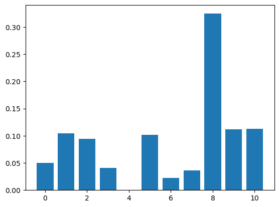

```python
# Barchat for feature importance
pyplot.bar([x for x in range(len(importance))], importance)
pyplot.show()
```

```python
prediction = dtc_model.predict(x_test) #prediction stores the predicted targets/classes
print (prediction)
```

```
[0 1 1 1 1 0 1 1 1 1 0 0 1 1 1 1 1 1 1 1 0 0 0 1 1 0 1 0 0 1 1 1 1 0 0 1 1
 0 0 1 0 1 1 1 1 0 1 0 1 0 0 1 1 1 0 1 0 0 0 1 1 1 1 0 1 1 1 0 1 1 0 0 0 1
 1 1 1 0 1 1 1 1 0 1 1 1 1 1 1 1 1 1 1 1 1 1 0 0 0 1 1 1 1 1 1 1 0 1 0 1 0
 1 1 1 0 0 1 1 1 1 0 1 0 1 0 1 0 0 1 0 0 1 0 1 1 0 1 0 0 0 0 1 0 1 1 0 0 0
 0 1 1 1 1 1 1 1 0 0 1 1 1 1 0 1 1 0 0 1 0 0 1 1 0 1 1 1 1 1 1 1 0 0]
```

```python
#both are converting 1 and 0 to Y and N

#Factual truth 100% correct
y_true = le.inverse_transform(y_test["Loan_Status"])

#what the models gives as True
y_pred = le.inverse_transform(prediction)
```

```
<sklearn.metrics._plot.confusion_matrix.ConfusionMatrixDisplay at 0x16aaeee90>
```

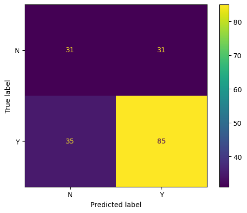

```python
cm = confusion_matrix(y_true, y_pred)
labels = ['N', 'Y']
ConfusionMatrixDisplay(cm, display_labels=labels).plot()
```

```python
print(classification_report(y_true, y_pred))
```

```
              precision    recall  f1-score   support

           N       0.47      0.50      0.48        62
           Y       0.73      0.71      0.72       120

    accuracy                           0.64       182
   macro avg       0.60      0.60      0.60       182
weighted avg       0.64      0.64      0.64       182
```

Visualising the decision tree

```python
from graphviz import Source
from sklearn import tree

graph = Source( tree.export_graphviz(dtc_model, out_file=None, feature_names=features.columns))
```

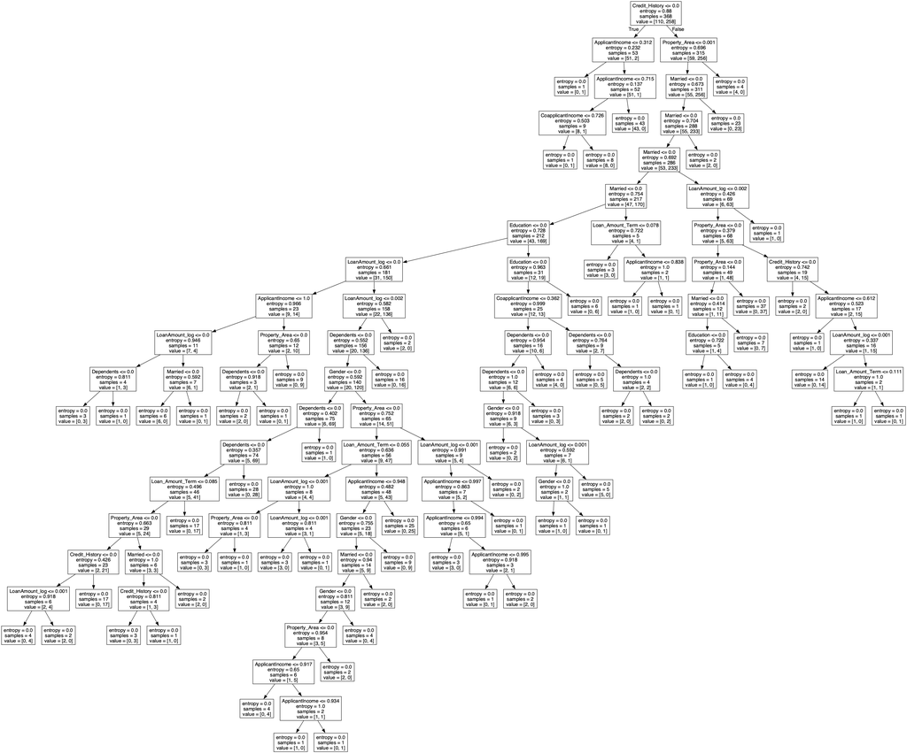

```python
from cairosvg import svg2png
from IPython.display import Image

svg2png(bytestring=graph.pipe(format='svg'),write_to='output.png')
Image("output.png")
```

Q6. Based on the feature importance, select a different set of features to build another dicision tree model. You should aim to improve the result of the baseline model.

```python
#revise on the feature importance

# feature importance
importance = dtc_model.feature_importances_

for i,v in enumerate(importance):
    print('Feature: %0d, Score: %.5f' % (i,v))
```

```
Feature: 0, Score: 0.05017
Feature: 1, Score: 0.10427
Feature: 2, Score: 0.09446
Feature: 3, Score: 0.04110
Feature: 4, Score: 0.00000
Feature: 5, Score: 0.10178
Feature: 6, Score: 0.02270
Feature: 7, Score: 0.03604
Feature: 8, Score: 0.32464
Feature: 9, Score: 0.11210
Feature: 10, Score: 0.11274
```

```python
selected_features = normalized_data[['Credit_History', 'LoanAmount_log', 'ApplicantIncome', 'Property_Area', 'Married']]
```

```python
print ('Selected Features:\n\n', selected_features.head())

#target class is the same 'Loan_Status'
print('Classes: \n\n' ,classes.head())
```

```
Selected Features:

    Credit_History  LoanAmount_log  ApplicantIncome  Property_Area   Married
0        0.000306        0.001343         0.993898       0.000613  0.000000
1        0.000000        0.001288         0.809478       0.000262  0.000262
2        0.000225        0.001064         0.769078       0.000225  0.000225
3        0.000456        0.001936         0.986453       0.000456  0.000000
4        0.000240        0.001172         0.711391       0.000240  0.000240
Classes:

    Loan_Status
0            1
1            0
2            1
3            1
4            1
```

```python
x_train, x_test, y_train, y_test = train_test_split(selected_features, classes, test_size= .33,
                                                    random_state = 4072)
print(x_train.shape, x_test.shape)
```

```
(368, 5) (182, 5)
```

```python
decisionTree = DecisionTreeClassifier(criterion='entropy')
print(decisionTree)
```

```
DecisionTreeClassifier(criterion='entropy')
```

```python
dtc_model = decisionTree.fit(x_train, y_train)
```

```python
# feature importance
importance = dtc_model.feature_importances_

for i,v in enumerate(importance):
    print('Feature: %0d, Score: %.5f' % (i,v))
```

```
Feature: 0, Score: 0.37062
Feature: 1, Score: 0.12529
Feature: 2, Score: 0.26532
Feature: 3, Score: 0.10372
Feature: 4, Score: 0.13504
```

```python
selected_features.head()
```

|  | Credit_History | LoanAmount_log | ApplicantIncome | Property_Area | Married |
| --- | --- | --- | --- | --- | --- |
| 0 | 0.000306 | 0.001343 | 0.993898 | 0.000613 | 0.000000 |
| 1 | 0.000000 | 0.001288 | 0.809478 | 0.000262 | 0.000262 |
| 2 | 0.000225 | 0.001064 | 0.769078 | 0.000225 | 0.000225 |
| 3 | 0.000456 | 0.001936 | 0.986453 | 0.000456 | 0.000000 |
| 4 | 0.000240 | 0.001172 | 0.711391 | 0.000240 | 0.000240 |

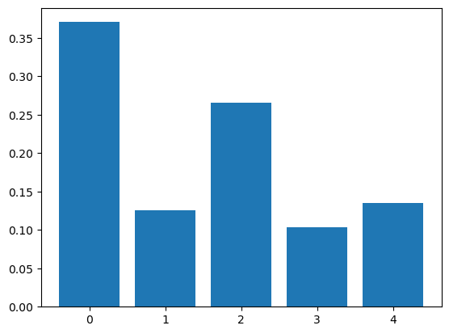

```python
# Barchat for feature importance
pyplot.bar([x for x in range(len(importance))], importance)
pyplot.show()
```

```python
#stores x_test into prediction
prediction = dtc_model.predict(x_test)
```

```python
y_true = le.inverse_transform(y_test["Loan_Status"])
y_pred = le.inverse_transform(prediction)
```

```
<sklearn.metrics._plot.confusion_matrix.ConfusionMatrixDisplay at 0x16ab3e150>
```

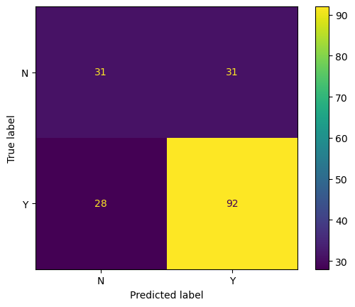

```python
cm = confusion_matrix(y_true, y_pred)
labels = ['N', 'Y']
ConfusionMatrixDisplay(cm, display_labels=labels).plot()
```

```python
print(classification_report(y_true, y_pred))
```

```
              precision    recall  f1-score   support

           N       0.53      0.50      0.51        62
           Y       0.75      0.77      0.76       120

    accuracy                           0.68       182
   macro avg       0.64      0.63      0.63       182
weighted avg       0.67      0.68      0.67       182
```

```python
#visulize the new tree
from graphviz import Source
from sklearn import tree
graph = Source( tree.export_graphviz(dtc_model, out_file=None, feature_names=selected_features.columns))
```

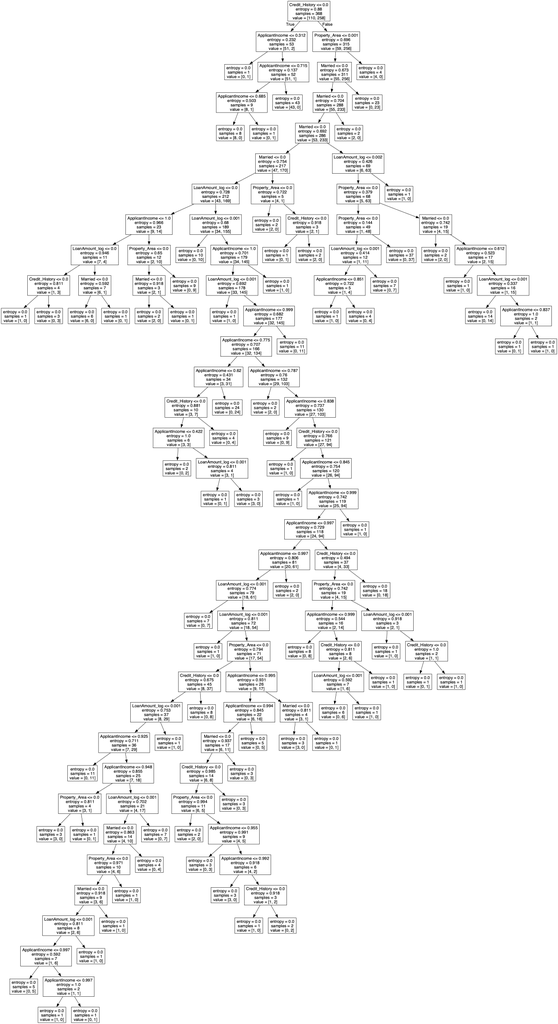

```python
from cairosvg import svg2png
from IPython.display import Image
svg2png(bytestring=graph.pipe(format='svg'),write_to='output.png')
Image("output.png")
```